# Machine Learning 2019: Tree-Based Methods

## Pruning using cross-validation

Pruning is a method to cut back the tree to prevent over-fitting.

```r
#cross-validation to prune the tree using cv.tree
cv.carseats = cv.tree(tree.carseats, FUN = prune.misclass)

#Sizes of the trees as they were pruned back, the deviances as the pruning proceeded, and cost complexity parameter used in the process.
cv.carseats
```

```
## $size
##  [1] 24 21 18 14 12  9  7  5  4  2  1
##
## $dev
##  [1]  69  68  63  65  69  73  76  75  83  92 104
##
## $k
##  [1] -Inf  0.0  1.0  1.5  2.5  3.0  3.5  4.0  6.0  7.5 25.0
##
## $method
## [1] "misclass"
##
## attr(,"class")
## [1] "prune"         "tree.sequence"
```

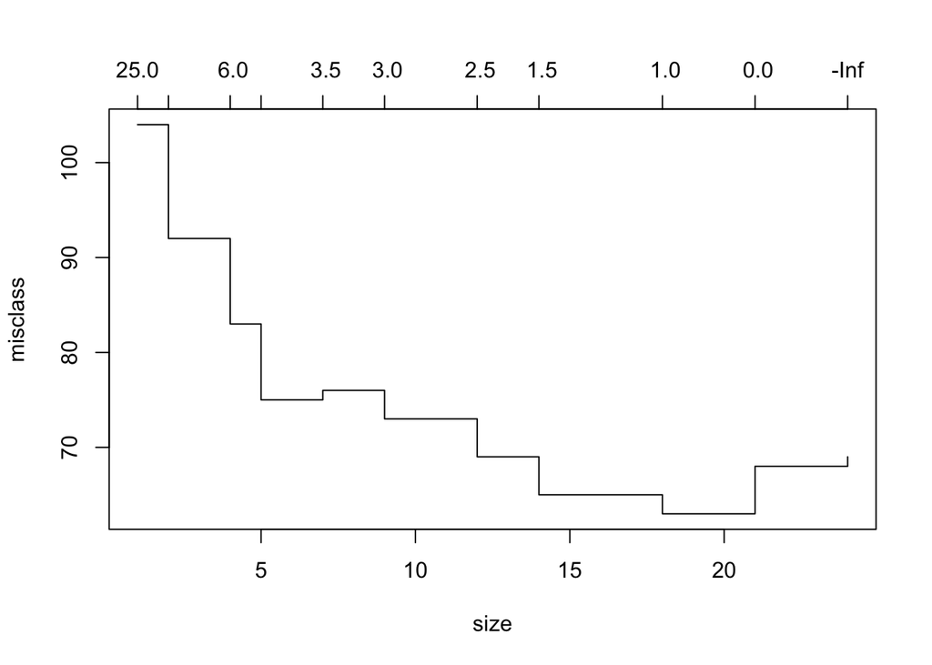

```r
#Visualize
plot(cv.carseats)
```

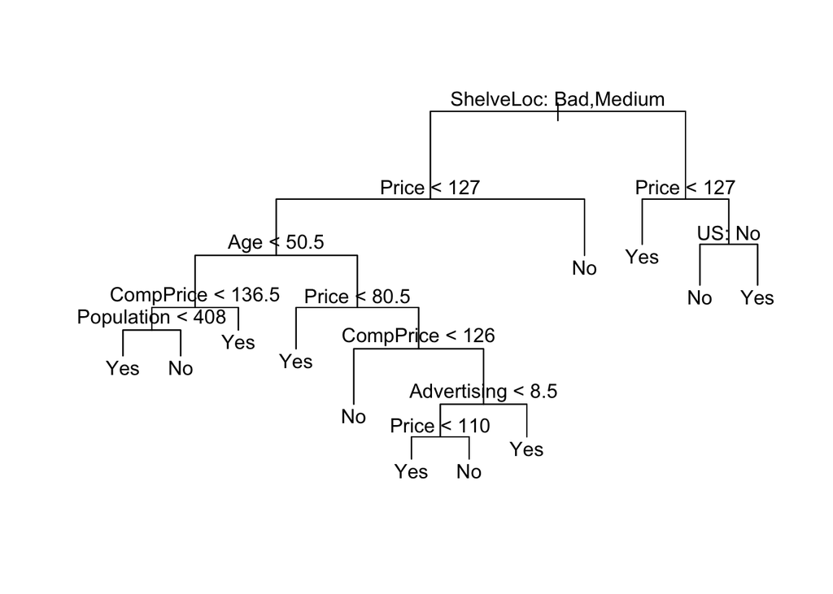

```r
#Prune tree to a size of 12
prune.carseats = prune.misclass(tree.carseats, best = 12)

#Visualize tree
plot(prune.carseats)
text(prune.carseats, pretty=0)
```

```r
#Evaluate on test set
tree.pred = predict(prune.carseats, carseats[-train,], type="class")

#Misclassification
with(carseats[-train,], table(tree.pred, High))
```

```
##          High
## tree.pred No Yes
##       No  66  21
##       Yes 22  41
```

```r
#Error
mc_pruning = (66 + 41) / 150
mc_pruning
```

```
## [1] 0.7133333
```

```r
##pruning did not increase misclassification error by too much and resulted in a simpler tree!!
```

Pruning did not increase misclassification error by too much and resulted in a simpler tree!!

Decision trees suffer from high variance, meaning if you split the training data into 2 parts at random, and fit a decision tree to both halves, the results that you get could be very different.

Bagging and boosting are technique used to reduce the variance of your predictions.

## The Boston Housing Dataset

506 Observations, 14 variables Response Variable: medv (median value of owner-occupied homes for each suburb)

```r
data("Boston")
boston = Boston
head(Boston)
```

|  | crim | zn | indus | chas | nox | rm | age | dis | rad | tax | ptratio | black | lstat | medv |
| --- | --- | --- | --- | --- | --- | --- | --- | --- | --- | --- | --- | --- | --- | --- |
| 1 | 0.00632 | 18 | 2.31 | 0 | 0.538 | 6.575 | 65.2 | 4.0900 | 1 | 296 | 15.3 | 396.90 | 4.98 | 24.0 |
| 2 | 0.02731 | 0 | 7.07 | 0 | 0.469 | 6.421 | 78.9 | 4.9671 | 2 | 242 | 17.8 | 396.90 | 9.14 | 21.6 |
| 3 | 0.02729 | 0 | 7.07 | 0 | 0.469 | 7.185 | 61.1 | 4.9671 | 2 | 242 | 17.8 | 392.83 | 4.03 | 34.7 |
| 4 | 0.03237 | 0 | 2.18 | 0 | 0.458 | 6.998 | 45.8 | 6.0622 | 3 | 222 | 18.7 | 394.63 | 2.94 | 33.4 |
| 5 | 0.06905 | 0 | 2.18 | 0 | 0.458 | 7.147 | 54.2 | 6.0622 | 3 | 222 | 18.7 | 396.90 | 5.33 | 36.2 |
| 6 | 0.02985 | 0 | 2.18 | 0 | 0.458 | 6.430 | 58.7 | 6.0622 | 3 | 222 | 18.7 | 394.12 | 5.21 | 28.7 |

## Bagging: Random Forest

Bagging involves creating multiple copies of the original training dataset using the bootstrap, fitting a separate decision tree to each copy, and then combining all of the trees in order to create a single predictive model. Each tree is built on a bootstrapped dataset, independent of the other trees.

Random Forest: Each time a split in a tree is considered, a random sample of m predictors is chosen as split candidates from the full set of p predictors. The split is allowed to use only one of those m predictors.

```r
#set seed for reproducibility
set.seed(29)

#split into train and test sets (300 and 206 respectively)
train = sample(1:nrow(boston), 300)

#fit training subset of data to model
rf.boston = randomForest(medv~., data = boston, subset = train)
rf.boston
```

```
##
## Call:
##  randomForest(formula = medv ~ ., data = boston, subset = train)
##                Type of random forest: regression
##                      Number of trees: 500
## No. of variables tried at each split: 4
##
##           Mean of squared residuals: 12.86824
##                     % Var explained: 83.94
```

[figure not shown]

```r
#summary of rf.boston gives information about the number of trees, the mean squared residuals (MSR), and the percentage of variance explained

#No. of variables tried at each split: 4
#Each time the tree comes to split a node, 4 variables would be selected at random, then the split would be confined to 1 of those 4 variables.

##Lets try a range of mtry (number of variables selected at random at each split)

oob.err = double(13)
test.err = double(13)

#In a loop of mtry from 1 to 13, you first fit the randomForest to the train dataset
for(mtry in 1:13){
  fit = randomForest(medv~., data = boston, subset=train, mtry=mtry, ntree = 350)
  oob.err[mtry] = fit$mse[350] ##extract Mean-squared-error
  pred = predict(fit, boston[-train,]) #predict on test dataset
  test.err[mtry] = with(boston[-train,], mean( (medv-pred)^2 )) #compute test error
}

#Visualize
matplot(1:mtry, cbind(test.err, oob.err), pch = 23, col = c("red", "blue"), type = "b", ylab="Mean Squared Error")
legend("topright", legend = c("OOB", "Test"), pch = 23, col = c("red", "blue"))
```

## Boosting

Boosting is another approach to improve the predictions resulting from a decision tree. Trees are grown sequentially: each tree is grown using information from previously grown trees. Each tree is fitted on a modified version of the original dataset.

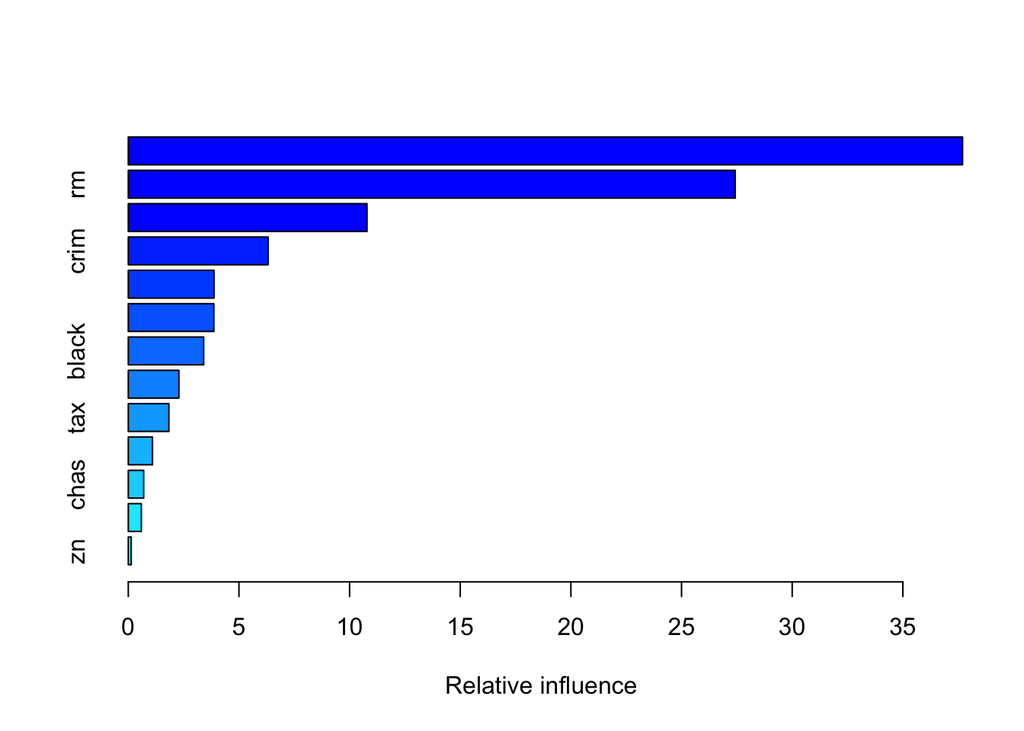

|  | var | rel.inf |
| --- | --- | --- |
| lstat | lstat | 37.6982917 |
| rm | rm | 27.4231506 |
| dis | dis | 10.7870570 |
| crim | crim | 6.3190588 |
| nox | nox | 3.8741970 |
| age | age | 3.8660387 |
| black | black | 3.4055088 |
| ptratio | ptratio | 2.2861013 |
| tax | tax | 1.8341376 |
| indus | indus | 1.0918593 |

[output cut: 3 more lines]

```r
#Gradient Boosting Model
boost.boston = gbm(medv~., data = boston[train,], distribution = "gaussian", n.trees = 10000, shrinkage = 0.01, interaction.depth = 4)

#Variable Importance Plot
summary(boost.boston)
```

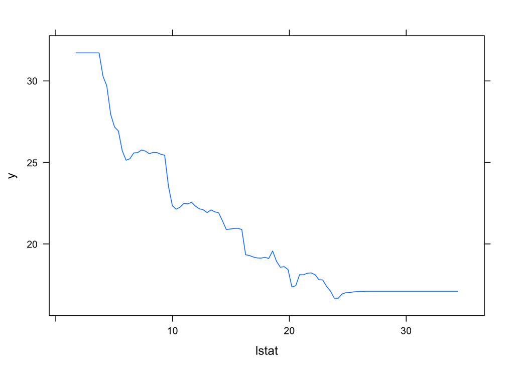

```r
#Visualize important variables of interest
plot(boost.boston,i="lstat")
```

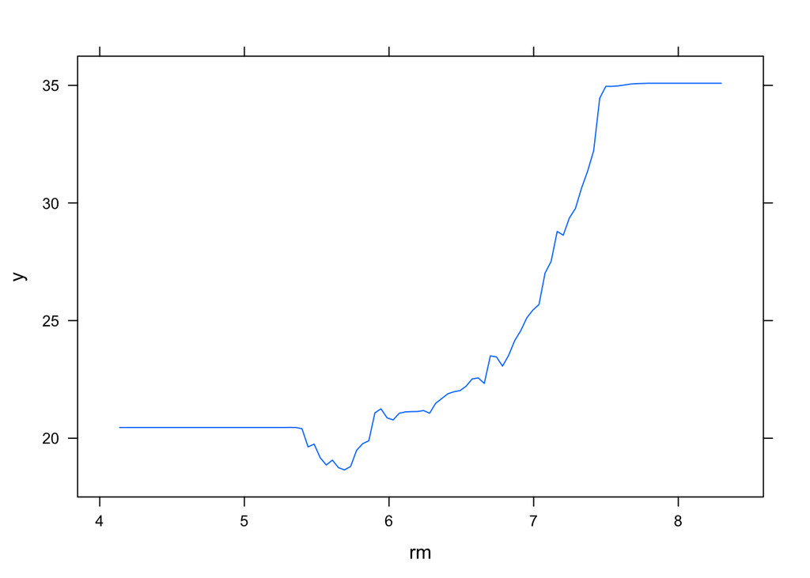

```r
plot(boost.boston,i="rm")
```

```r
#Predict on test set
n.trees = seq(from = 100, to = 10000, by = 100)
predmat = predict(boost.boston, newdata = boston[-train,], n.trees = n.trees)
dim(predmat)
```

```
## [1] 206 100
```

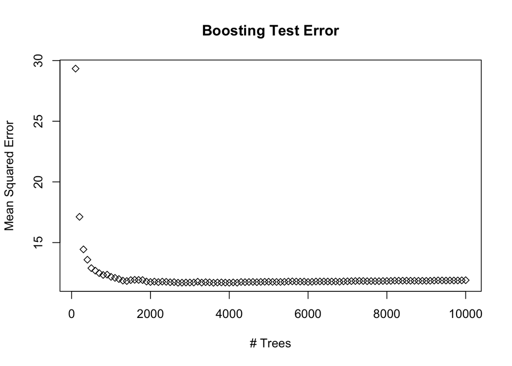

```r
#Visualize Boosting Error Plot
boost.err = with(boston[-train,], apply( (predmat - medv)^2, 2, mean) )
plot(n.trees, boost.err, pch = 23, ylab = "Mean Squared Error", xlab = "# Trees", main = "Boosting Test Error")
abline(h = min(test.err), col = "red")
```

## Homework

1. Attempt a regression tree-based method (not covered in this tutorial) on a reasonable dataset of your choice. Explain the results.

```r
library(rpart)
```

A regression tree was created for the boston housing data. The target value is medv which is median value of owner-occupied homes in USD 1000’s. Key varibles were rm ( average number of rooms per dwelling), lstat(percentage of lower status of the population), and dis (weighted distances to five Boston employment centres). A regression tree paritions it into smaller groups. If we bag the tree, we can decrease its variance.

```r
fit <- rpart(medv ~ .-medv, method="anova", data=boston)

printcp(fit)
```

```
##
## Regression tree:
## rpart(formula = medv ~ . - medv, data = boston, method = "anova")
##
## Variables actually used in tree construction:
## [1] crim  dis   lstat rm
##
## Root node error: 42716/506 = 84.42
##
## n= 506
##
##         CP nsplit rel error  xerror     xstd
## 1 0.452744      0   1.00000 1.00501 0.083239
## 2 0.171172      1   0.54726 0.65507 0.058882
## 3 0.071658      2   0.37608 0.43331 0.047732
## 4 0.036164      3   0.30443 0.34557 0.042713
## 5 0.033369      4   0.26826 0.33350 0.043431
## 6 0.026613      5   0.23489 0.33434 0.043694
## 7 0.015851      6   0.20828 0.30595 0.041026
## 8 0.010000      7   0.19243 0.26583 0.031885
```

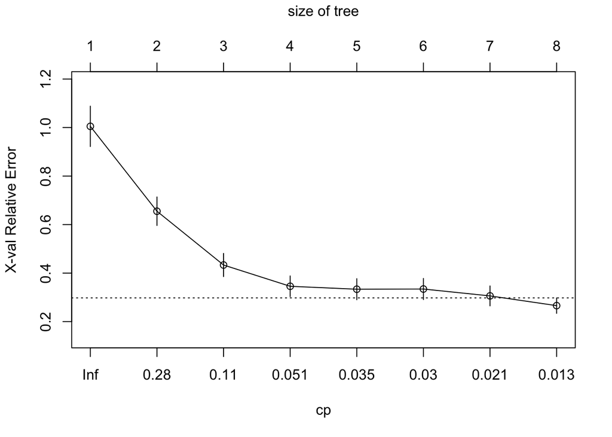

```r
plotcp(fit)
```

```r
summary(fit)
```

```
## Call:
## rpart(formula = medv ~ . - medv, data = boston, method = "anova")
##   n= 506
##
##           CP nsplit rel error    xerror       xstd
## 1 0.45274420      0 1.0000000 1.0050051 0.08323926
## 2 0.17117244      1 0.5472558 0.6550705 0.05888246
## 3 0.07165784      2 0.3760834 0.4333050 0.04773196
## 4 0.03616428      3 0.3044255 0.3455697 0.04271274
## 5 0.03336923      4 0.2682612 0.3334992 0.04343145
## 6 0.02661300      5 0.2348920 0.3343351 0.04369395
## 7 0.01585116      6 0.2082790 0.3059545 0.04102617
## 8 0.01000000      7 0.1924279 0.2658285 0.03188481
##
## Variable importance
##      rm   lstat     dis   indus     tax ptratio     nox     age    crim
##      33      21       7       7       6       6       6       6       4
##      zn     rad   black
##       2       1       1
##
## Node number 1: 506 observations,    complexity param=0.4527442
##   mean=22.53281, MSE=84.41956
##   left son=2 (430 obs) right son=3 (76 obs)
##   Primary splits:
##       rm      < 6.941    to the left,  improve=0.4527442, (0 missing)
##       lstat   < 9.725    to the right, improve=0.4423650, (0 missing)
##       indus   < 6.66     to the right, improve=0.2594613, (0 missing)
##       ptratio < 19.9     to the right, improve=0.2443727, (0 missing)
##       nox     < 0.6695   to the right, improve=0.2232456, (0 missing)
##   Surrogate splits:
##       lstat   < 4.83     to the right, agree=0.891, adj=0.276, (0 split)
##       ptratio < 14.55    to the right, agree=0.875, adj=0.171, (0 split)
##       zn      < 87.5     to the left,  agree=0.862, adj=0.079, (0 split)
##       indus   < 1.605    to the right, agree=0.862, adj=0.079, (0 split)
##       crim    < 0.013355 to the right, agree=0.852, adj=0.013, (0 split)
##
## Node number 2: 430 observations,    complexity param=0.1711724
##   mean=19.93372, MSE=40.27284
##   left son=4 (175 obs) right son=5 (255 obs)
##   Primary splits:
```

[output cut: 95 more lines]

```
##
## Node number 11: 7 observations
##   mean=38, MSE=204.1457
##
## Node number 12: 7 observations
##   mean=23.05714, MSE=61.85673
##
## Node number 13: 39 observations
##   mean=33.73846, MSE=20.24391
##
## Node number 20: 193 observations
##   mean=21.65648, MSE=8.23738
##
## Node number 21: 55 observations
##   mean=27.42727, MSE=11.69398
```